# NPP, GPP, and Rh Processing and Inital Analysis

## Input Data

Because the lat and lon coordinates are formatted funky we are going to want to modify them so that they are easier to work with.

Save a data frame of the area per coordinates.

Calculate the annual mean flux, in theory the dimensions should not change because this is annual data. This is a precautionary step just incase the results for a single year were split over mulitple files.

Since the units are currently the average kg C m^-2 s^-1 for a year let's convert them to g C m^-2 yr^-1

Calculate the global rate.

Make some diagnositc plots to make sure that. The results make sense and are consistent.

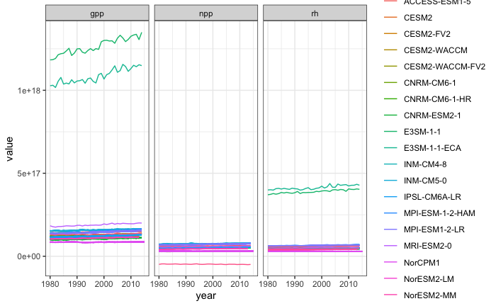

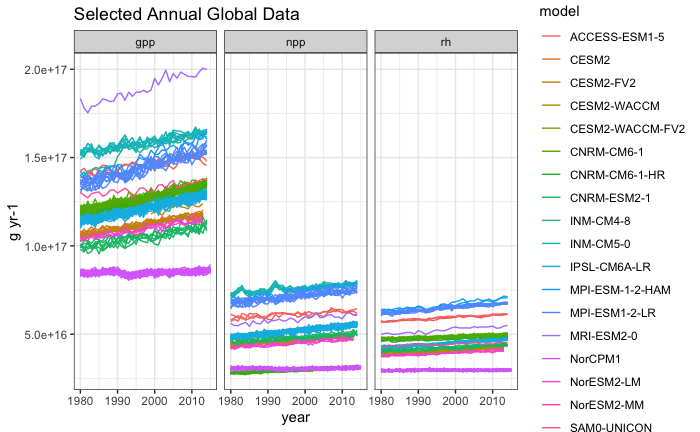

Make a quick plot of the lat / lon data for a single year.

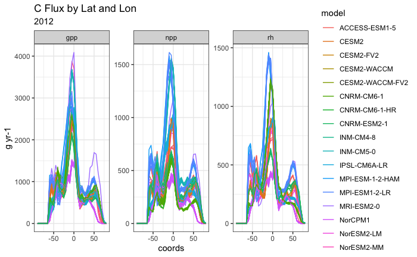

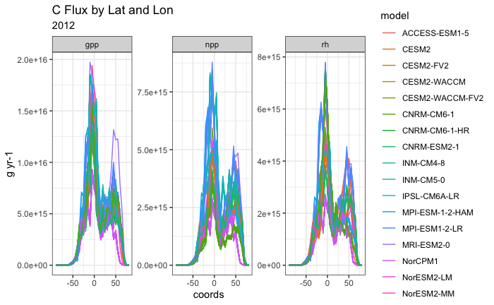

## Calculate the Percent of Global Total.

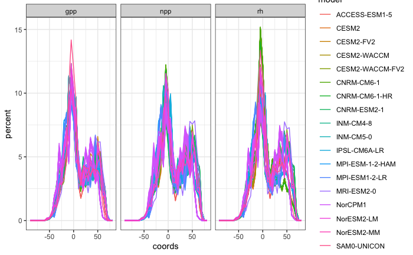

## Format

Now that our data looks decent let's save the data. For simplicity's sake let's save a copy of each of the time series by variable.

Next save a copy of the raw lat and lon values.

Save information about the area per sampled region.